# Recruitment Parameters Module Bootcamp

## Introduction

This document is an additional guideline to the recruitment module of the *simple* package. It can act like a bootcamp providing you with hands-on experience. Below will be some tasks of increasing complexity to make you comfortable using the module and find out difficulties.

## Recap

To help you remember the essentials of the module’s functionality a short summary is provided. For further information on the module, please read the vignette first.

### Function arguments

The module will have global variables as well as specific arguments that can be added and specified in the recruitment function

#### Global variables `lGlobVars`

Global variables are inputs that are used in different modules and change during the simulation. (for example the current time). The vignette of the *lGlobVars* module will include an overview of all global Variables.

#### Additional arguments `lAddArgs`

Apart from global variables, module specific variables can be added. (These could be distribution parameters or a cap for the maximum number of patients to be included in the trial)

### Functions

#### Constructor Function `new_lRecrPars`

The idea is to be able to include global variables of the simulation as well as any additional variable you would want to impact your recruitment.

The central function of the module is `new_lRecrPars`. It defines the “rules” of recruitment you want to implement in the simulation.

#### Helper function `lRecrPars`

If you do not want to think about a recruitment strategy, you can use the helper function `lRecrPars` which simulates a standard scenario.

### Plot

The plot function acts as a proxy for an actual simulation. Plotting objects created by `lRecrPars` or `new_lRecrPars` displays the development of patients recruitment as well as the number of active arms over time.

### Summary

The summary call provides information about the input you provided. It gives an overview about global and additional variables as well the function that was implemented.

## Tasks

Try to use the module to program the following tasks according to the instructions. You can display the solution upon clicking the *code* button. The examples of the vignette may serve as a helping hand. The plots below show what the plotted output could look like.

**1. Create a scenario, where the number of patients recruited is taken from a binomial distribution with n = 20 and p = 0.2**

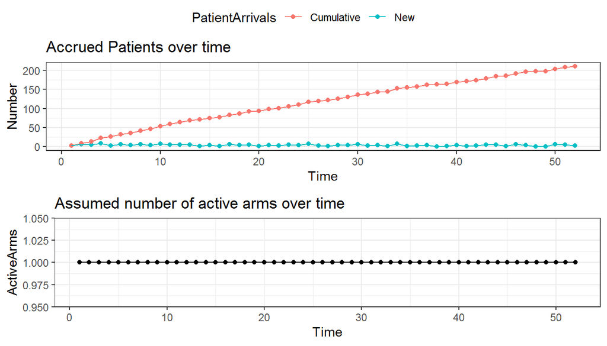

```r
x <- new_lRecrPars(
  fnRecrProc = function(lGlobVars, lAddArgs){
    n_pat = rbinom(1, lAddArgs$n, lAddArgs$prob)
  },

  lAddArgs = list(n = 20,
                  prob = 0.2)
)
plot(x)
```

**2. Create a scenario where every 3rd time units the number of patients recruited corresponds to the current time unit. In the remaining time units recruitment is stopped.**

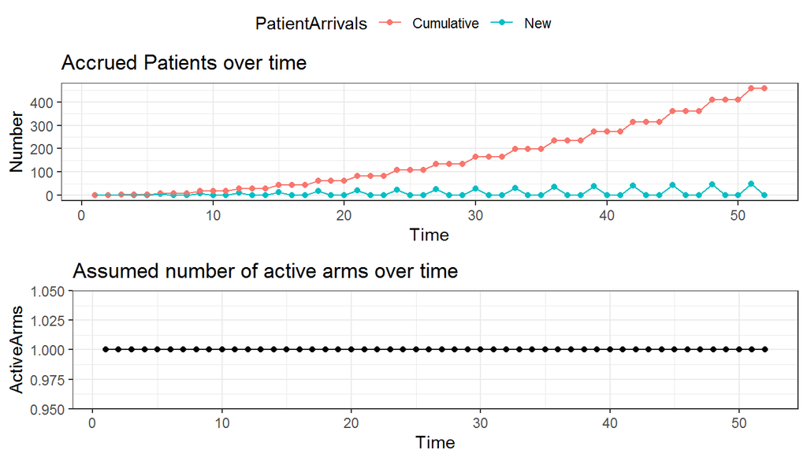

```r
x <- new_lRecrPars(
  fnRecrProc = function(lGlobVars, lAddArgs){
    n_pat <- lGlobVars$lVars$dCurrTime * lGlobVars$lVars$bEnrOpen
  }

)

plot(x,
     bEnrOpen = c(rep(c(FALSE, FALSE, TRUE), length.out = 52)))
```

```r
# # Alternatively:
# x <- new_lRecrPars(
#   fnRecrProc = function(lGlobVars, lAddArgs){
#     if(lGlobVars$lVars$dCurrTime %% 3 == 0){
#       n_pat <- lGlobVars$lVars$dCurrTime
#     } else {
#       n_pat <- 0
#     }
#   }
# )
#
# plot(x)
```

**3. Create a scenario where the number of patients recruited is drawn from a poisson distribution. The distribution parameter *lambda* depends on the number of active arms and the time period.**

**For time period 1-40: lambda = 5* number of active arms**

**For time period 41-52: lambda = 10* number of active arms**

**For time period 1-10: number of active arms = 1**

**For time period 11-30: number of active arms = 2**

**For time period 31-52: number of active arms = 3**

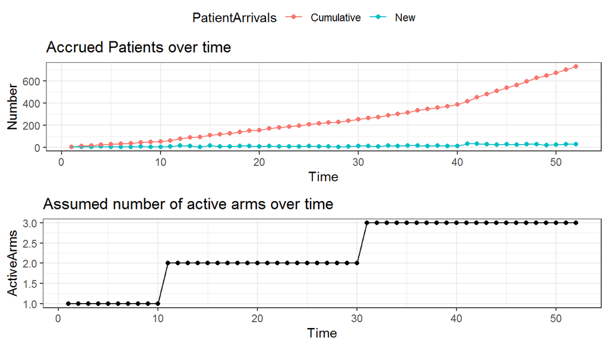

```r
x <- new_lRecrPars(
  fnRecrProc = function(lGlobVars, lAddArgs){
    if(lGlobVars$lVars$dCurrTime <= 40){
      n_pat <- rpois(1, lambda = lAddArgs$lambda1 * lGlobVars$lVars$dActvIntr)
    } else {
      n_pat <- rpois(1, lambda = lAddArgs$lambda2 * lGlobVars$lVars$dActvIntr)
    }
  },

  lAddArgs = list(lambda1 = 5,
                  lambda2 = 10)
)

plot(x,
     dActvIntr = c(rep(1, 10), rep(2, 20), rep(3, 22)))
```

### Remarks

Notice in scenario 1 the values of n and p could be directly written into the *rbinom* function without stating them in the *lAddArgs* argument. Perks of stating them in *lAddArgs* are the appearance in an overview you might want to print using summary() as well as efficiency if these arguments are used more than once. Notice the alternative implementation of Task 2 in the solution, suggesting there are many ways of implementing a scenario depending on your programming preferences.

The global variables saved in the list *lGlobVars* have a fixed name which can not be changed as it is implemented in many different modules. As mentioned above the vignette of the module *lGlobVars* will contain an overview of all the global variables used in any module. The naming convention consists of lowerCamelCase with the first part being a letter describing the data type of the object(l = list, b = bool, v = vector, d = number)